# Practical Machine Learning Project : Prediction Assignment Writeup

AF

## Background

Using devices such as Jawbone Up, Nike FuelBand, and Fitbit it is now possible to collect a large amount of data about personal activity relatively inexpensively. These type of devices are part of the quantified self movement – a group of enthusiasts who take measurements about themselves regularly to improve their health, to find patterns in their behavior, or because they are tech geeks. One thing that people regularly do is quantify how much of a particular activity they do, but they rarely quantify how well they do it. In this project, your goal will be to use data from accelerometers on the belt, forearm, arm, and dumbell of 6 participants. They were asked to perform barbell lifts correctly and incorrectly in 5 different ways. More information is available from the website here: http://web.archive.org/web/20161224072740/http:/groupware.les.inf.puc-rio.br/har (see the section on the Weight Lifting Exercise Dataset).

## Goal

The goal of your project is to predict the manner in which they did the exercise. This is the “classe” variable in the training set. You may use any of the other variables to predict with. You should create a report describing how you built your model, how you used cross validation, what you think the expected out of sample error is, and why you made the choices you did. You will also use your prediction model to predict 20 different test cases.

## Data

The data for this project come from this source: http://web.archive.org/web/20161224072740/http:/groupware.les.inf.puc-rio.br/har.

## Loading data and required packages

```r
library(caret)
```

```r
library(rpart)
library(rpart.plot)
library(RColorBrewer)
library(rattle)
library(randomForest)
library(knitr)
```

```r
training <- read.csv('./pml-training.csv', header=T)
testing <- read.csv('./pml-testing.csv', header=T)
dim(training)
```

```
## [1] 19622   160
```

```r
dim(testing)
```

```
## [1]  20 160
```

```r
str(training)
```

```
## 'data.frame':    19622 obs. of  160 variables:
##  $ X                       : int  1 2 3 4 5 6 7 8 9 10 ...
##  $ user_name               : Factor w/ 6 levels "adelmo","carlitos",..: 2 2 2 2 2 2 2 2 2 2 ...
##  $ raw_timestamp_part_1    : int  1323084231 1323084231 1323084231 1323084232 1323084232 1323084232 1323084232 1323084232 1323084232 1323084232 ...
##  $ raw_timestamp_part_2    : int  788290 808298 820366 120339 196328 304277 368296 440390 484323 484434 ...
##  $ cvtd_timestamp          : Factor w/ 20 levels "02/12/2011 13:32",..: 9 9 9 9 9 9 9 9 9 9 ...
##  $ new_window              : Factor w/ 2 levels "no","yes": 1 1 1 1 1 1 1 1 1 1 ...
##  $ num_window              : int  11 11 11 12 12 12 12 12 12 12 ...
##  $ roll_belt               : num  1.41 1.41 1.42 1.48 1.48 1.45 1.42 1.42 1.43 1.45 ...
##  $ pitch_belt              : num  8.07 8.07 8.07 8.05 8.07 8.06 8.09 8.13 8.16 8.17 ...
##  $ yaw_belt                : num  -94.4 -94.4 -94.4 -94.4 -94.4 -94.4 -94.4 -94.4 -94.4 -94.4 ...
##  $ total_accel_belt        : int  3 3 3 3 3 3 3 3 3 3 ...
##  $ kurtosis_roll_belt      : Factor w/ 397 levels "","-0.016850",..: 1 1 1 1 1 1 1 1 1 1 ...
##  $ kurtosis_picth_belt     : Factor w/ 317 levels "","-0.021887",..: 1 1 1 1 1 1 1 1 1 1 ...
##  $ kurtosis_yaw_belt       : Factor w/ 2 levels "","#DIV/0!": 1 1 1 1 1 1 1 1 1 1 ...
```

[output cut: 86 more lines]

Both datasets have 160 variables. The training data set has NA values or blank values in some of the columns so we will need to remove them.

## Cleaining data

Let’s remove the variables that contain missing values

```r
dataTrain <- training[, colSums(is.na(training)) == 0]
dataTest<- testing[, colSums(is.na(testing)) == 0]
dim(dataTrain)
```

```
## [1] 19622    93
```

```r
dim(dataTest)
```

```
## [1] 20 60
```

Next let’s remove the first 7 variables that are considered as identification variables and have little affect on the outcome classe

```r
dataTrain <- dataTrain[, -c(1:7)]
dataTest <- dataTest[, -c(1:7)]

# Show remaning clumns
colnames(dataTrain)
```

```
##  [1] "roll_belt"               "pitch_belt"
##  [3] "yaw_belt"                "total_accel_belt"
##  [5] "kurtosis_roll_belt"      "kurtosis_picth_belt"
##  [7] "kurtosis_yaw_belt"       "skewness_roll_belt"
##  [9] "skewness_roll_belt.1"    "skewness_yaw_belt"
## [11] "max_yaw_belt"            "min_yaw_belt"
## [13] "amplitude_yaw_belt"      "gyros_belt_x"
## [15] "gyros_belt_y"            "gyros_belt_z"
## [17] "accel_belt_x"            "accel_belt_y"
## [19] "accel_belt_z"            "magnet_belt_x"
## [21] "magnet_belt_y"           "magnet_belt_z"
## [23] "roll_arm"                "pitch_arm"
## [25] "yaw_arm"                 "total_accel_arm"
## [27] "gyros_arm_x"             "gyros_arm_y"
## [29] "gyros_arm_z"             "accel_arm_x"
```

[output cut: 28 more lines]

```r
colnames(dataTest)
```

```
##  [1] "roll_belt"            "pitch_belt"           "yaw_belt"
##  [4] "total_accel_belt"     "gyros_belt_x"         "gyros_belt_y"
##  [7] "gyros_belt_z"         "accel_belt_x"         "accel_belt_y"
## [10] "accel_belt_z"         "magnet_belt_x"        "magnet_belt_y"
## [13] "magnet_belt_z"        "roll_arm"             "pitch_arm"
## [16] "yaw_arm"              "total_accel_arm"      "gyros_arm_x"
## [19] "gyros_arm_y"          "gyros_arm_z"          "accel_arm_x"
## [22] "accel_arm_y"          "accel_arm_z"          "magnet_arm_x"
## [25] "magnet_arm_y"         "magnet_arm_z"         "roll_dumbbell"
## [28] "pitch_dumbbell"       "yaw_dumbbell"         "total_accel_dumbbell"
## [31] "gyros_dumbbell_x"     "gyros_dumbbell_y"     "gyros_dumbbell_z"
## [34] "accel_dumbbell_x"     "accel_dumbbell_y"     "accel_dumbbell_z"
## [37] "magnet_dumbbell_x"    "magnet_dumbbell_y"    "magnet_dumbbell_z"
## [40] "roll_forearm"         "pitch_forearm"        "yaw_forearm"
## [43] "total_accel_forearm"  "gyros_forearm_x"      "gyros_forearm_y"
## [46] "gyros_forearm_z"      "accel_forearm_x"      "accel_forearm_y"
## [49] "accel_forearm_z"      "magnet_forearm_x"     "magnet_forearm_y"
## [52] "magnet_forearm_z"     "problem_id"
```

```r
dim(dataTrain)
```

```
## [1] 19622    86
```

```r
dim(dataTest)
```

```
## [1] 20 53
```

```r
set.seed(12345)
inTrain <- createDataPartition(dataTrain$classe, p = 0.7, list = FALSE)
dataTrain <- dataTrain[inTrain, ]
dataTest <- dataTrain[-inTrain, ]
dim(dataTrain)
```

```
## [1] 13737    86
```

```r
dim(dataTest)
```

```
## [1] 4110   86
```

Let’s remove the Near Zero Variance variables.

```r
nZeroVar <- nearZeroVar(dataTrain)
dataTrain <- dataTrain[, -nZeroVar]
dataTest <- dataTest[, -nZeroVar]
dim(dataTrain)
```

```
## [1] 13737    53
```

```r
dim(dataTest)
```

```
## [1] 4110   53
```

This leaves us with 53 variables.

## Prediction using Decision Trees

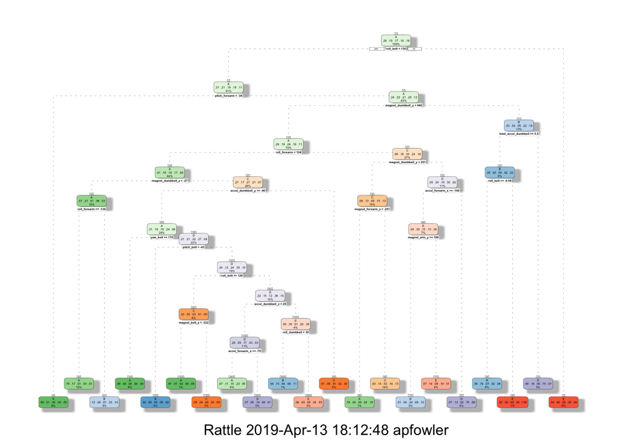

```r
set.seed(12345)
trainTree <- rpart(classe ~ ., data = dataTrain, method = "class")
fancyRpartPlot(trainTree)
```

Let’s validate the tree model on the dataTest to find out how well it performs

```r
testTree <- predict(trainTree, dataTest, type = "class")
confusionTree <- confusionMatrix(testTree, dataTest$classe)
confusionTree
```

```
## Confusion Matrix and Statistics
##
##           Reference
## Prediction    A    B    C    D    E
##          A 1047  117   41   77   15
##          B   32  500   63   64   65
##          C   30   90  556   97   84
##          D   27   53   50  382   28
##          E   25   42    9   86  530
##
## Overall Statistics
##
##                Accuracy : 0.7336
##                  95% CI : (0.7198, 0.747)
##     No Information Rate : 0.2825
##     P-Value [Acc > NIR] : < 2.2e-16
##
##                   Kappa : 0.6618
##
##  Mcnemar's Test P-Value : < 2.2e-16
##
## Statistics by Class:
##
##                      Class: A Class: B Class: C Class: D Class: E
## Sensitivity            0.9018   0.6234   0.7733  0.54108   0.7341
## Specificity            0.9152   0.9323   0.9112  0.95358   0.9522
## Pos Pred Value         0.8072   0.6906   0.6488  0.70741   0.7659
## Neg Pred Value         0.9595   0.9108   0.9499  0.90924   0.9438
## Prevalence             0.2825   0.1951   0.1749  0.17178   0.1757
## Detection Rate         0.2547   0.1217   0.1353  0.09294   0.1290
## Detection Prevalence   0.3156   0.1762   0.2085  0.13139   0.1684
## Balanced Accuracy      0.9085   0.7779   0.8423  0.74733   0.8431
```

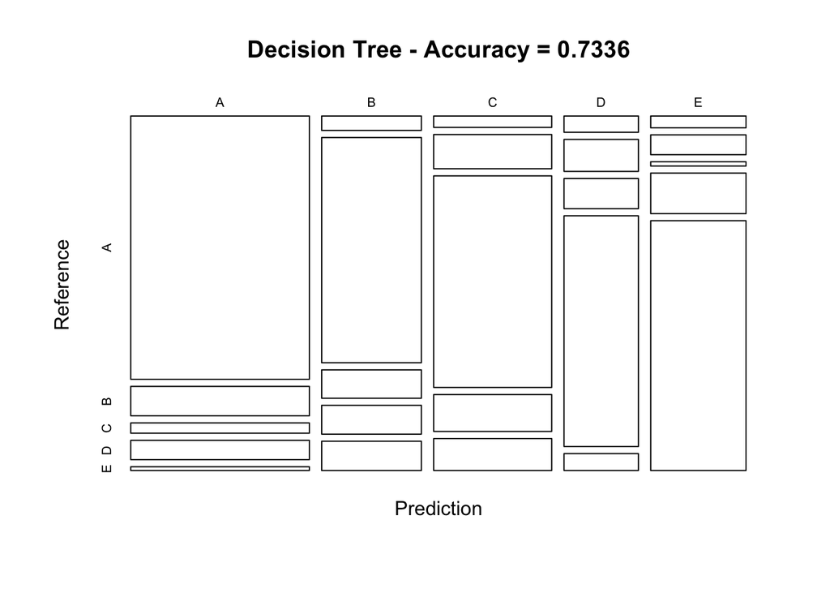

```r
plot(confusionTree$table, col = confusionTree$byClass,
     main = paste("Decision Tree - Accuracy =",
                  round(confusionTree$overall['Accuracy'], 4)))
```

The accuracy rate of the model is 0.7336.

## Prediction using Random Forest

```r
ranForest <-  randomForest(classe ~ ., dataTrain)
testForest <- predict(ranForest, dataTest, type = "class")
confusionFor <- confusionMatrix(testForest, dataTest$classe)
confusionFor
```

```
## Confusion Matrix and Statistics
##
##           Reference
## Prediction    A    B    C    D    E
##          A 1161    0    0    0    0
##          B    0  802    0    0    0
##          C    0    0  719    0    0
##          D    0    0    0  706    0
##          E    0    0    0    0  722
##
## Overall Statistics
##
##                Accuracy : 1
##                  95% CI : (0.9991, 1)
##     No Information Rate : 0.2825
##     P-Value [Acc > NIR] : < 2.2e-16
##
##                   Kappa : 1
##
##  Mcnemar's Test P-Value : NA
##
## Statistics by Class:
##
##                      Class: A Class: B Class: C Class: D Class: E
## Sensitivity            1.0000   1.0000   1.0000   1.0000   1.0000
## Specificity            1.0000   1.0000   1.0000   1.0000   1.0000
## Pos Pred Value         1.0000   1.0000   1.0000   1.0000   1.0000
## Neg Pred Value         1.0000   1.0000   1.0000   1.0000   1.0000
## Prevalence             0.2825   0.1951   0.1749   0.1718   0.1757
## Detection Rate         0.2825   0.1951   0.1749   0.1718   0.1757
## Detection Prevalence   0.2825   0.1951   0.1749   0.1718   0.1757
## Balanced Accuracy      1.0000   1.0000   1.0000   1.0000   1.0000
```

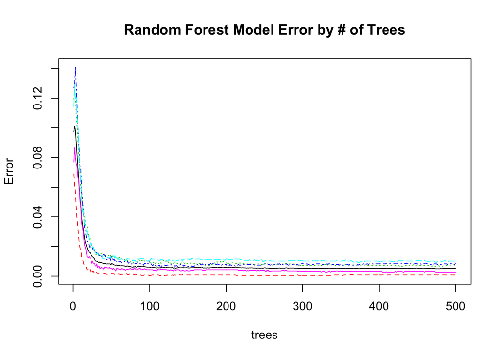

```r
plot(ranForest, main = "Random Forest Model Error by # of Trees")
```

## Out of Sample Error

```r
OUSerror <- predict(ranForest,dataTest)
acc <- sum(OUSerror == dataTest$classe) / length(OUSerror)
print(acc)
```

```
## [1] 1
```

Plotting matrix results

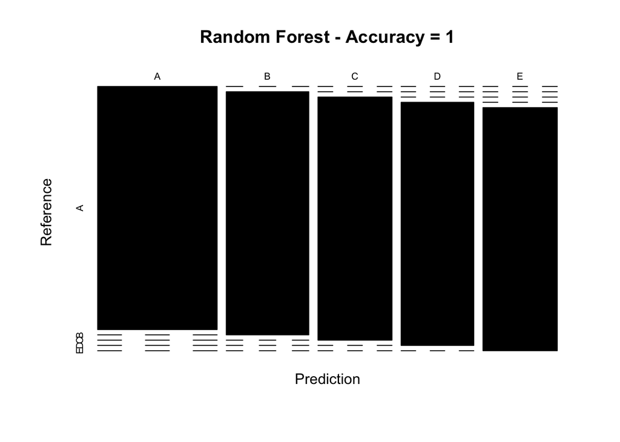

```r
plot(confusionFor$table, col = confusionFor$byClass,
     main = paste("Random Forest - Accuracy =",
                  round(confusionFor$overall['Accuracy'], 4)))
```

## Prediction with Boosting method

```r
gbmFit<- train(classe ~ ., method ="gbm", data = dataTrain, verbose = FALSE)
gbmFit
```

```
## Stochastic Gradient Boosting
##
## 13737 samples
##    52 predictor
##     5 classes: 'A', 'B', 'C', 'D', 'E'
##
## No pre-processing
## Resampling: Bootstrapped (25 reps)
## Summary of sample sizes: 13737, 13737, 13737, 13737, 13737, 13737, ...
## Resampling results across tuning parameters:
##
##   interaction.depth  n.trees  Accuracy   Kappa
##   1                   50      0.7535536  0.6873264
##   1                  100      0.8193904  0.7713325
##   1                  150      0.8526205  0.8134056
##   2                   50      0.8539797  0.8149117
##   2                  100      0.9050426  0.8797702
##   2                  150      0.9299003  0.9112633
##   3                   50      0.8947807  0.8667376
##   3                  100      0.9398819  0.9239037
##   3                  150      0.9582319  0.9471408
##
## Tuning parameter 'shrinkage' was held constant at a value of 0.1
##
## Tuning parameter 'n.minobsinnode' was held constant at a value of 10
## Accuracy was used to select the optimal model using the largest value.
## The final values used for the model were n.trees = 150,
##  interaction.depth = 3, shrinkage = 0.1 and n.minobsinnode = 10.
```

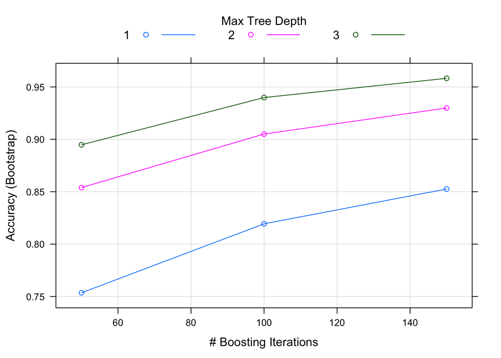

```r
# Plot results
plot(gbmFit)
```

```r
predictTrain <- predict(gbmFit, newdata = dataTest)
confusionGBM <- confusionMatrix(dataTest$classe, predictTrain)
confusionGBM$table
```

```
##           Reference
## Prediction    A    B    C    D    E
##          A 1151    6    3    1    0
##          B   19  775    8    0    0
##          C    0   18  693    7    1
##          D    0    3   17  685    1
##          E    2    6    7    3  704
```

```r
# GBM Accuracy
confusionGBM$overall[1]
```

```
##  Accuracy
## 0.9751825
```

GBM accuracy is 0.9751

## Predicting results using Test Data

From this, we see that Random Forest is the best to predict and should be applied to predict the 20 quiz results shown below:

```r
predictTesting <- predict(ranForest, newdata = testing)
predictTesting
```

```
##  1  2  3  4  5  6  7  8  9 10 11 12 13 14 15 16 17 18 19 20
##  B  A  B  A  A  E  D  B  A  A  B  C  B  A  E  E  A  B  B  B
## Levels: A B C D E
```